# Project: Investigate a Dataset (No Show Appointments 2016)

- Introduction
- Data Wrangling
- Exploratory Data Analysis
- Conclusions

## Introduction

On daily basis, people tend to make reservations for doctors appointments before going to avoid waiting a long time. Some people tend to reserve an appointment and never show up, which affects doctors utilization with patients.

In this project, a dataset of 100K patients were collected in Brazil in 2016. We will try to understand the charactraristics of no show patients by investigating the dataset and try to predict if a patient will show or not show on his/her reserved appointment.

### Questions

1. is there a relation between neighbourhood and no show ?

2. What are the charactaristics of no show hipertension patients ?

3. Which age category has the highest no show proportion ?

```python
# Use this cell to set up import statements for all of the packages that you
#   plan to use.
import pandas as pd
import matplotlib.pyplot as plt
import numpy as np
import seaborn as sns
sns.set(style="darkgrid")

%matplotlib inline
```

## Data Wrangling

### General Properties

```python
# Load your data and print out a few lines. Perform operations to inspect data
#   types and look for instances of missing or possibly errant data.
df = pd.read_csv('noshow.csv')
df.head(5)
```

|  | PatientId | AppointmentID | Gender | ScheduledDay | AppointmentDay | Age | Neighbourhood | Scholarship | Hipertension | Diabetes | Alcoholism | Handcap | SMS_received | No-show |
| --- | --- | --- | --- | --- | --- | --- | --- | --- | --- | --- | --- | --- | --- | --- |
| 0 | 2.987250e+13 | 5642903 | F | 2016-04-29T18:38:08Z | 2016-04-29T00:00:00Z | 62 | JARDIM DA PENHA | 0 | 1 | 0 | 0 | 0 | 0 | No |
| 1 | 5.589978e+14 | 5642503 | M | 2016-04-29T16:08:27Z | 2016-04-29T00:00:00Z | 56 | JARDIM DA PENHA | 0 | 0 | 0 | 0 | 0 | 0 | No |
| 2 | 4.262962e+12 | 5642549 | F | 2016-04-29T16:19:04Z | 2016-04-29T00:00:00Z | 62 | MATA DA PRAIA | 0 | 0 | 0 | 0 | 0 | 0 | No |
| 3 | 8.679512e+11 | 5642828 | F | 2016-04-29T17:29:31Z | 2016-04-29T00:00:00Z | 8 | PONTAL DE CAMBURI | 0 | 0 | 0 | 0 | 0 | 0 | No |
| 4 | 8.841186e+12 | 5642494 | F | 2016-04-29T16:07:23Z | 2016-04-29T00:00:00Z | 56 | JARDIM DA PENHA | 0 | 1 | 1 | 0 | 0 | 0 | No |

### Dataframe has 110527 rows and 14 columns

```python
df.shape
```

```
(110527, 14)
```

### Data frame has no null values in any row

```python
df.info()
```

```
<class 'pandas.core.frame.DataFrame'>
RangeIndex: 110527 entries, 0 to 110526
Data columns (total 14 columns):
PatientId         110527 non-null float64
AppointmentID     110527 non-null int64
Gender            110527 non-null object
ScheduledDay      110527 non-null object
AppointmentDay    110527 non-null object
Age               110527 non-null int64
Neighbourhood     110527 non-null object
Scholarship       110527 non-null int64
Hipertension      110527 non-null int64
Diabetes          110527 non-null int64
Alcoholism        110527 non-null int64
Handcap           110527 non-null int64
SMS_received      110527 non-null int64
No-show           110527 non-null object
dtypes: float64(1), int64(8), object(5)
memory usage: 11.8+ MB
```

```python
df.describe()
```

|  | PatientId | AppointmentID | Age | Scholarship | Hipertension | Diabetes | Alcoholism | Handcap | SMS_received |
| --- | --- | --- | --- | --- | --- | --- | --- | --- | --- |
| count | 1.105270e+05 | 1.105270e+05 | 110527.000000 | 110527.000000 | 110527.000000 | 110527.000000 | 110527.000000 | 110527.000000 | 110527.000000 |
| mean | 1.474963e+14 | 5.675305e+06 | 37.088874 | 0.098266 | 0.197246 | 0.071865 | 0.030400 | 0.022248 | 0.321026 |
| std | 2.560949e+14 | 7.129575e+04 | 23.110205 | 0.297675 | 0.397921 | 0.258265 | 0.171686 | 0.161543 | 0.466873 |
| min | 3.921784e+04 | 5.030230e+06 | -1.000000 | 0.000000 | 0.000000 | 0.000000 | 0.000000 | 0.000000 | 0.000000 |
| 25% | 4.172614e+12 | 5.640286e+06 | 18.000000 | 0.000000 | 0.000000 | 0.000000 | 0.000000 | 0.000000 | 0.000000 |
| 50% | 3.173184e+13 | 5.680573e+06 | 37.000000 | 0.000000 | 0.000000 | 0.000000 | 0.000000 | 0.000000 | 0.000000 |
| 75% | 9.439172e+13 | 5.725524e+06 | 55.000000 | 0.000000 | 0.000000 | 0.000000 | 0.000000 | 0.000000 | 1.000000 |
| max | 9.999816e+14 | 5.790484e+06 | 115.000000 | 1.000000 | 1.000000 | 1.000000 | 1.000000 | 4.000000 | 1.000000 |

### Dataframe has no duplicated values

```python
df[df.duplicated()]
```

|  | PatientId | AppointmentID | Gender | ScheduledDay | AppointmentDay | Age | Neighbourhood | Scholarship | Hipertension | Diabetes | Alcoholism | Handcap | SMS_received | No-show |
| --- | --- | --- | --- | --- | --- | --- | --- | --- | --- | --- | --- | --- | --- | --- |

## Data Cleaning

### Dropping PatientId and AppointmentID columns as they are not relevant to this analysis

```python
# After discussing the structure of the data and any problems that need to be
#   cleaned, perform those cleaning steps in the second part of this section.
df.drop(['PatientId', 'AppointmentID'], axis = 1, inplace = True)
df.head()
```

|  | Gender | ScheduledDay | AppointmentDay | Age | Neighbourhood | Scholarship | Hipertension | Diabetes | Alcoholism | Handcap | SMS_received | No-show |
| --- | --- | --- | --- | --- | --- | --- | --- | --- | --- | --- | --- | --- |
| 0 | F | 2016-04-29T18:38:08Z | 2016-04-29T00:00:00Z | 62 | JARDIM DA PENHA | 0 | 1 | 0 | 0 | 0 | 0 | No |
| 1 | M | 2016-04-29T16:08:27Z | 2016-04-29T00:00:00Z | 56 | JARDIM DA PENHA | 0 | 0 | 0 | 0 | 0 | 0 | No |
| 2 | F | 2016-04-29T16:19:04Z | 2016-04-29T00:00:00Z | 62 | MATA DA PRAIA | 0 | 0 | 0 | 0 | 0 | 0 | No |
| 3 | F | 2016-04-29T17:29:31Z | 2016-04-29T00:00:00Z | 8 | PONTAL DE CAMBURI | 0 | 0 | 0 | 0 | 0 | 0 | No |
| 4 | F | 2016-04-29T16:07:23Z | 2016-04-29T00:00:00Z | 56 | JARDIM DA PENHA | 0 | 1 | 1 | 0 | 0 | 0 | No |

### Changing all column names to lower case

```python
df.columns = [x.lower() for x in df.columns]
df.head()
```

|  | gender | scheduledday | appointmentday | age | neighbourhood | scholarship | hipertension | diabetes | alcoholism | handcap | sms_received | no-show |
| --- | --- | --- | --- | --- | --- | --- | --- | --- | --- | --- | --- | --- |
| 0 | F | 2016-04-29T18:38:08Z | 2016-04-29T00:00:00Z | 62 | JARDIM DA PENHA | 0 | 1 | 0 | 0 | 0 | 0 | No |
| 1 | M | 2016-04-29T16:08:27Z | 2016-04-29T00:00:00Z | 56 | JARDIM DA PENHA | 0 | 0 | 0 | 0 | 0 | 0 | No |
| 2 | F | 2016-04-29T16:19:04Z | 2016-04-29T00:00:00Z | 62 | MATA DA PRAIA | 0 | 0 | 0 | 0 | 0 | 0 | No |
| 3 | F | 2016-04-29T17:29:31Z | 2016-04-29T00:00:00Z | 8 | PONTAL DE CAMBURI | 0 | 0 | 0 | 0 | 0 | 0 | No |
| 4 | F | 2016-04-29T16:07:23Z | 2016-04-29T00:00:00Z | 56 | JARDIM DA PENHA | 0 | 1 | 1 | 0 | 0 | 0 | No |

### Changing no-show column to no_show

```python
def columnRenamer(dataframe, currentName, newName):
    dataframe.rename(columns= {currentName:newName}, inplace = True)
    return dataframe.head()

columnRenamer(df, 'no-show', 'no_show')
```

|  | gender | scheduledday | appointmentday | age | neighbourhood | scholarship | hipertension | diabetes | alcoholism | handcap | sms_received | no_show |
| --- | --- | --- | --- | --- | --- | --- | --- | --- | --- | --- | --- | --- |
| 0 | F | 2016-04-29T18:38:08Z | 2016-04-29T00:00:00Z | 62 | JARDIM DA PENHA | 0 | 1 | 0 | 0 | 0 | 0 | No |
| 1 | M | 2016-04-29T16:08:27Z | 2016-04-29T00:00:00Z | 56 | JARDIM DA PENHA | 0 | 0 | 0 | 0 | 0 | 0 | No |
| 2 | F | 2016-04-29T16:19:04Z | 2016-04-29T00:00:00Z | 62 | MATA DA PRAIA | 0 | 0 | 0 | 0 | 0 | 0 | No |
| 3 | F | 2016-04-29T17:29:31Z | 2016-04-29T00:00:00Z | 8 | PONTAL DE CAMBURI | 0 | 0 | 0 | 0 | 0 | 0 | No |
| 4 | F | 2016-04-29T16:07:23Z | 2016-04-29T00:00:00Z | 56 | JARDIM DA PENHA | 0 | 1 | 1 | 0 | 0 | 0 | No |

### Dropping reservations that has a negative value between scheduled day and appointment day as it will make no sense

```python
#https://stackoverflow.com/questions/33377182/how-to-find-the-number-of-days-between-two-dates-for-dataframe-manipulation

t1 = pd.to_datetime(df.appointmentday)
t2 = pd.to_datetime(df.scheduledday)

days = (t1 - t2) / pd.offsets.Day(1)
days = days.astype('int')
df['numdays'] = days
```

Below histogram shows that some data has invalid time value as some durations are in negative values.

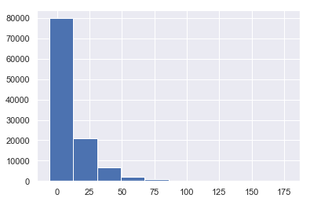

```python
df['numdays'].hist();
```

```python
#invalid time rows
invalid_rows = df.query('numdays < 0')
invalid_rows
```

|  | gender | scheduledday | appointmentday | age | neighbourhood | scholarship | hipertension | diabetes | alcoholism | handcap | sms_received | no_show | numdays |
| --- | --- | --- | --- | --- | --- | --- | --- | --- | --- | --- | --- | --- | --- |
| 27033 | M | 2016-05-10T10:51:53Z | 2016-05-09T00:00:00Z | 38 | RESISTÊNCIA | 0 | 0 | 0 | 0 | 1 | 0 | Yes | -1 |
| 55226 | F | 2016-05-18T14:50:41Z | 2016-05-17T00:00:00Z | 19 | SANTO ANTÔNIO | 0 | 0 | 0 | 0 | 1 | 0 | Yes | -1 |
| 64175 | F | 2016-05-05T13:43:58Z | 2016-05-04T00:00:00Z | 22 | CONSOLAÇÃO | 0 | 0 | 0 | 0 | 0 | 0 | Yes | -1 |
| 71533 | F | 2016-05-11T13:49:20Z | 2016-05-05T00:00:00Z | 81 | SANTO ANTÔNIO | 0 | 0 | 0 | 0 | 0 | 0 | Yes | -6 |
| 72362 | M | 2016-05-04T06:50:57Z | 2016-05-03T00:00:00Z | 7 | TABUAZEIRO | 0 | 0 | 0 | 0 | 0 | 0 | Yes | -1 |

```python
#dropping invalid time rows
df.drop(invalid_rows.index, inplace = True)
df.info()
```

```
<class 'pandas.core.frame.DataFrame'>
Int64Index: 110522 entries, 0 to 110526
Data columns (total 13 columns):
gender            110522 non-null object
scheduledday      110522 non-null object
appointmentday    110522 non-null object
age               110522 non-null int64
neighbourhood     110522 non-null object
scholarship       110522 non-null int64
hipertension      110522 non-null int64
diabetes          110522 non-null int64
alcoholism        110522 non-null int64
handcap           110522 non-null int64
sms_received      110522 non-null int64
no_show           110522 non-null object
numdays           110522 non-null int32
dtypes: int32(1), int64(7), object(5)
memory usage: 11.4+ MB
```

### Dropping invalid age and outliers

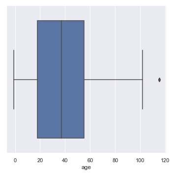

```python
sns.catplot(x="age", kind="box", data=df);
```

```python
age = df.query('age  < 0 or age >100')
age
```

|  | gender | scheduledday | appointmentday | age | neighbourhood | scholarship | hipertension | diabetes | alcoholism | handcap | sms_received | no_show | numdays |
| --- | --- | --- | --- | --- | --- | --- | --- | --- | --- | --- | --- | --- | --- |
| 58014 | F | 2016-05-03T09:14:53Z | 2016-05-03T00:00:00Z | 102 | CONQUISTA | 0 | 0 | 0 | 0 | 0 | 0 | No | 0 |
| 63912 | F | 2016-05-16T09:17:44Z | 2016-05-19T00:00:00Z | 115 | ANDORINHAS | 0 | 0 | 0 | 0 | 1 | 0 | Yes | 2 |
| 63915 | F | 2016-05-16T09:17:44Z | 2016-05-19T00:00:00Z | 115 | ANDORINHAS | 0 | 0 | 0 | 0 | 1 | 0 | Yes | 2 |
| 68127 | F | 2016-04-08T14:29:17Z | 2016-05-16T00:00:00Z | 115 | ANDORINHAS | 0 | 0 | 0 | 0 | 1 | 0 | Yes | 37 |
| 76284 | F | 2016-05-30T09:44:51Z | 2016-05-30T00:00:00Z | 115 | ANDORINHAS | 0 | 0 | 0 | 0 | 1 | 0 | No | 0 |
| 90372 | F | 2016-05-31T10:19:49Z | 2016-06-02T00:00:00Z | 102 | MARIA ORTIZ | 0 | 0 | 0 | 0 | 0 | 0 | No | 1 |
| 97666 | F | 2016-05-19T07:57:56Z | 2016-06-03T00:00:00Z | 115 | SÃO JOSÉ | 0 | 1 | 0 | 0 | 0 | 1 | No | 14 |
| 99832 | F | 2016-06-06T08:58:13Z | 2016-06-06T00:00:00Z | -1 | ROMÃO | 0 | 0 | 0 | 0 | 0 | 0 | No | 0 |

```python
df.drop(age.index, inplace = True)
```

### Changing no_show values to 0 and 1 instead of no and Yes

```python
#https://medium.com/jbennetcodes/how-to-rewrite-your-sql-queries-in-pandas-and-more-149d341fc53e
df.loc[df['no_show']== 'Yes', 'no_show'] = '1'
df.loc[df['no_show']== 'No', 'no_show'] = '0'

df.no_show = df.no_show.astype(int)
df.groupby('no_show').mean()
```

| no_show | age | scholarship | hipertension | diabetes | alcoholism | handcap | sms_received | numdays |
| --- | --- | --- | --- | --- | --- | --- | --- | --- |
| 0 | 37.787297 | 0.093908 | 0.204392 | 0.073841 | 0.030418 | 0.022732 | 0.291339 | 8.171820 |
| 1 | 34.307023 | 0.115548 | 0.169065 | 0.064094 | 0.030344 | 0.020080 | 0.438528 | 14.915961 |

Histogram below is showing that all data are in the acceptible range, no invalid age or outliers. We can see from the graph below that most of the customers made thier reservations within a day and 3 weeks We can see that the highest proportion of patients were kids

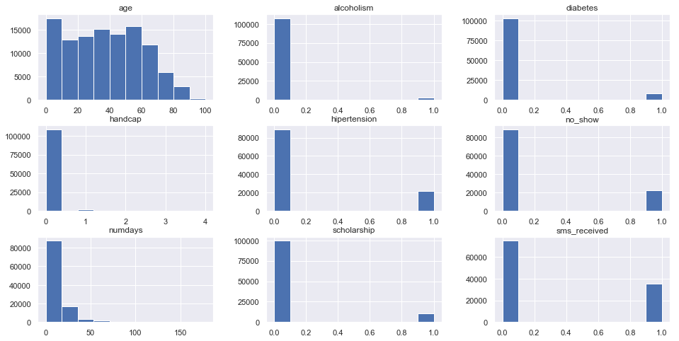

```python
df.hist(figsize = (16,8));
```

### Categorizing age

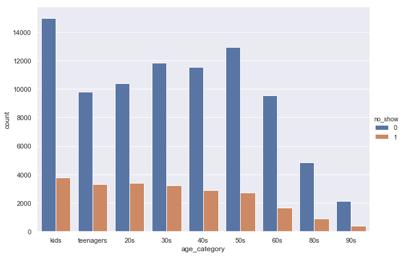

```python
#https://stackoverflow.com/questions/38936854/categorize-data-in-a-column-in-dataframe

df['age_category'] = pd.cut(df['age'], bins= np.arange(0,99,10), include_lowest=True, labels=['kids', 'teenagers', '20s','30s','40s','50s','60s','80s','90s'])

sns.catplot(x="age_category" , hue="no_show", kind="count", data=df, height=6, aspect=11.7/8.27);
```

## Exploratory Data Analysis

### Research Question 1: is there a relation between neighbourhood and no show ?

```python
#Creating 2 seperate lists for total people who showed and who didnt show

totalshow = df.query('no_show == 0')
totalnoshow = df.query('no_show == 1')
```

```python
#Exporting the value counts of number of people who showed and didnt show to a new csv file to study it seperately
totalshow.groupby('neighbourhood')['no_show'].value_counts().to_csv('neighbourtotalshow.csv',header = True)
totalnoshow.groupby('neighbourhood')['no_show'].value_counts().to_csv('neighbourtotalnoshow.csv', header = True)
```

```python
#exporting and cleaning the data
dfNeighbourShow = pd.read_csv('neighbourtotalshow.csv')
dfNeighbourShow.drop(['no_show'], axis = 1, inplace = True)
columnRenamer(dfNeighbourShow,'no_show.1','show')
```

|  | neighbourhood | show |
| --- | --- | --- |
| 0 | AEROPORTO | 7 |
| 1 | ANDORINHAS | 1740 |
| 2 | ANTÔNIO HONÓRIO | 221 |
| 3 | ARIOVALDO FAVALESSA | 220 |
| 4 | BARRO VERMELHO | 332 |

```python
dfNeighbourNoShow = pd.read_csv('neighbourtotalnoshow.csv')
dfNeighbourNoShow.drop(['no_show'], axis = 1, inplace = True)
columnRenamer(dfNeighbourNoShow,'no_show.1','noshow')
```

|  | neighbourhood | noshow |
| --- | --- | --- |
| 0 | AEROPORTO | 1 |
| 1 | ANDORINHAS | 518 |
| 2 | ANTÔNIO HONÓRIO | 50 |
| 3 | ARIOVALDO FAVALESSA | 62 |
| 4 | BARRO VERMELHO | 91 |

```python
#merging both lists for easier comparison
mergedNeighbourList = dfNeighbourNoShow.merge(dfNeighbourShow)
mergedNeighbourList.head()
```

|  | neighbourhood | noshow | show |
| --- | --- | --- | --- |
| 0 | AEROPORTO | 1 | 7 |
| 1 | ANDORINHAS | 518 | 1740 |
| 2 | ANTÔNIO HONÓRIO | 50 | 221 |
| 3 | ARIOVALDO FAVALESSA | 62 | 220 |
| 4 | BARRO VERMELHO | 91 | 332 |

```python
#calculating the proportions of no show people in each neighbourhood
mergedNeighbourList['proportions'] = mergedNeighbourList['noshow'] / mergedNeighbourList['show']
```

```python
mergedNeighbourList.describe()
```

|  | noshow | show | proportions |
| --- | --- | --- | --- |
| count | 79.000000 | 79.000000 | 79.000000 |
| mean | 282.392405 | 1116.481013 | 0.248720 |
| std | 277.900020 | 1096.053162 | 0.049526 |
| min | 1.000000 | 7.000000 | 0.093750 |
| 25% | 81.500000 | 328.500000 | 0.219923 |
| 50% | 190.000000 | 710.000000 | 0.246243 |
| 75% | 428.500000 | 1648.000000 | 0.277183 |
| max | 1465.000000 | 6252.000000 | 0.406836 |

```python
sortedNeighbourList = mergedNeighbourList.sort_values('proportions', ascending = False)
sortedNeighbourList.head()
```

|  | neighbourhood | noshow | show | proportions |
| --- | --- | --- | --- | --- |
| 68 | SANTOS DUMONT | 369 | 907 | 0.406836 |
| 59 | SANTA CECÍLIA | 123 | 325 | 0.378462 |
| 60 | SANTA CLARA | 134 | 372 | 0.360215 |
| 35 | ITARARÉ | 923 | 2591 | 0.356233 |
| 39 | JESUS DE NAZARETH | 696 | 2157 | 0.322670 |

### Plotting top 5 neighbourhoods that people do not come to appointments

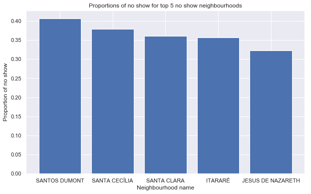

```python
plt.bar(sortedNeighbourList.head().neighbourhood, sortedNeighbourList.head().proportions)
plt.title("Proportions of no show for top 5 no show neighbourhoods")
plt.xlabel("Neighbourhood name")
plt.ylabel("Proportion of no show")
plt.gcf().set_size_inches(10,6)
```

### Research Question 2 : What are the charactaristics of no show hipertension patients ?

```python
df.groupby('hipertension').mean()
```

| hipertension | age | scholarship | diabetes | alcoholism | handcap | sms_received | no_show | numdays |
| --- | --- | --- | --- | --- | --- | --- | --- | --- |
| 0 | 31.303458 | 0.101190 | 0.016424 | 0.022916 | 0.015770 | 0.322520 | 0.208975 | 9.673220 |
| 1 | 60.611101 | 0.086422 | 0.297523 | 0.060872 | 0.048349 | 0.315092 | 0.173028 | 8.964174 |

The graph below is showing the relation between hipertension and age. We can easily find out that kids and teenagers have no hipertension, it starts with a very small percentage of patients in the 20s and reaches its maximum proportions in the 90s as the number of patients in the 90s with hipertension is double the patients that have no hipertension.

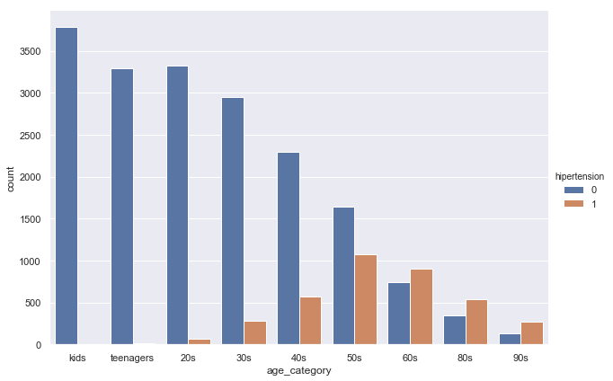

```python
sns.catplot(x="age_category" , hue="hipertension", kind="count", data=totalnoshow, height=6, aspect=11.7/8.27);
```

```python
hiperMeanShow = df.groupby('hipertension')['no_show'].mean()
```

[figure not shown]

```python
plt.bar(["Show", 'No Show'], hiperMeanShow)
plt.title("Proportion of hipertension customers")
plt.xlabel("Hipertension patients")
plt.ylabel("Proportion");
```

```python
hiperMeanAge = df.groupby('hipertension')['age'].mean()
hiperMeanAge
```

```
hipertension
0    31.303458
1    60.611101
Name: age, dtype: float64
```

Below graph is showing that the average age differs highly for hipertension patients as their mean value is 60 years while no hipertension patients mean is 30 years

[figure not shown]

```python
plt.bar(["Show", 'No Show'], hiperMeanAge)
plt.title("Mean age of hipertension customers")
plt.xlabel("Hipertension patients")
plt.ylabel("Age (Years)");
```

### Iventigating the diabitic condition for hipertension patients who show and no show to appointments

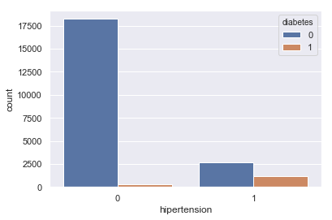

```python
sns.countplot(data = totalnoshow, x = 'hipertension', hue = 'diabetes');
```

### Investigating in the no show dataset only the mean of diabetic patients in the hipertension and no hipertension patients.

```python
hiperMeanDiabetes = totalnoshow.groupby('hipertension')['diabetes'].mean()
hiperMeanDiabetes
```

```
hipertension
0    0.015589
1    0.302492
Name: diabetes, dtype: float64
```

The following graph is showing that diabetes is higher among hipertension patients as its 1% only in no hipertension patients while 30% of hipertension patients have diabetes as well.

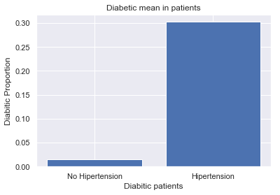

```python
plt.bar(["No Hipertension", 'Hipertension'], hiperMeanDiabetes)
plt.title("Diabetic mean in patients")
plt.xlabel("Diabitic patients")
plt.ylabel("Diabitic Proportion");
```

### Question 3: Which age category has the highest no show proportion ?

```python
totalshow['age_category'].value_counts()
```

```
kids         14961
50s          12940
30s          11820
40s          11550
20s          10389
teenagers     9791
60s           9541
80s           4832
90s           2137
Name: age_category, dtype: int64
```

```python
totalnoshow['age_category'].value_counts()
```

```
kids         3787
20s          3393
teenagers    3307
30s          3231
40s          2870
50s          2721
60s          1648
80s           889
90s           406
Name: age_category, dtype: int64
```

```python
proportionsAge = totalnoshow['age_category'].value_counts()/totalshow['age_category'].value_counts()
proportionsAge.sort_values(ascending = False, inplace = True)
proportionsAge
```

```
teenagers    0.337759
20s          0.326595
30s          0.273350
kids         0.253125
40s          0.248485
50s          0.210278
90s          0.189986
80s          0.183982
60s          0.172728
Name: age_category, dtype: float64
```

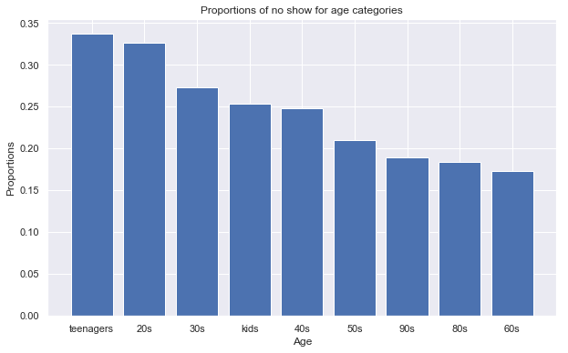

```python
plt.bar(proportionsAge.index, proportionsAge)
plt.title("Proportions of no show for age categories")
plt.xlabel("Age")
plt.ylabel("Proportions");
plt.gcf().set_size_inches(10,6)
```

## Conclusions

### Limitations

1. Most of our data is categorical which is limiting our search results.

2. The appointment day value is recorded as same hour and min and second for all patients, which might lead to incorrect reservations made but were not visible.

```python
from subprocess import call
call(['python', '-m', 'nbconvert', 'Investigate_a_Dataset.ipynb'])
```

```
4294967295
```